# Coursera: Reproducible Research - Project 1

Kate Stone

December 5, 2018

## Loading and preprocessing the data

```r
activity <- read.csv("activity.csv")
```

## 1. What is mean total number of steps taken per day?

### 1.1. Calculate total number of steps taken per day

```r
StepsPerDay <- tapply(activity$steps, activity$date, sum)
```

### 1.2. Make a histogram of the total number of steps taken each day

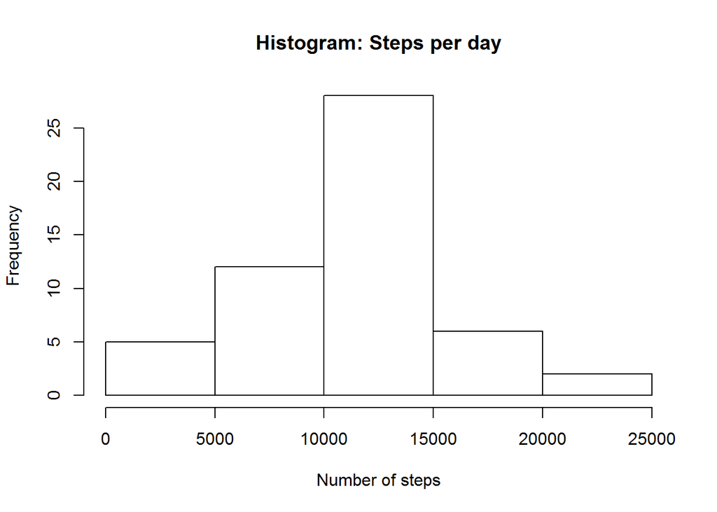

```r
hist(StepsPerDay, xlab = "Number of steps", main = "Histogram: Steps per day")
```

```r
Mean <- mean(StepsPerDay, na.rm = TRUE)
Median <- median(StepsPerDay, na.rm = TRUE)
```

## 2. What is the average daily activity pattern?

### 2.1 Make a time series plot of the 5-minute interval (x-axis) and the average number of steps taken, averaged across all days (y-axis)

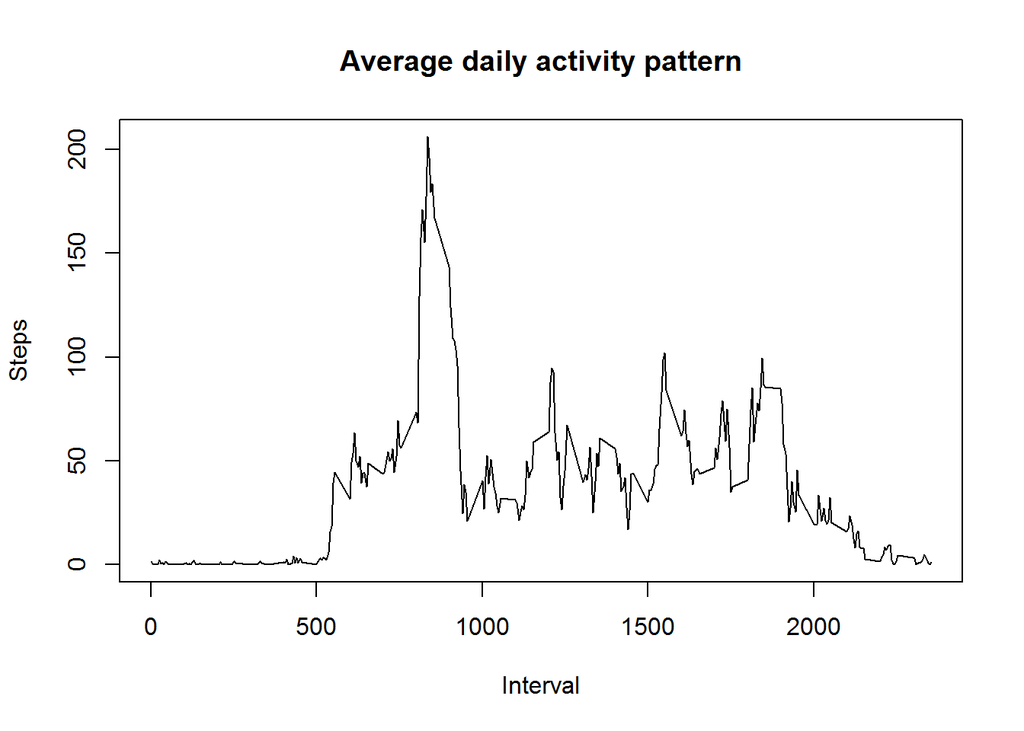

```r
StepsPerInterval <- tapply(activity$steps, activity$interval, mean, na.rm = TRUE)
plot(as.numeric(names(StepsPerInterval)), StepsPerInterval, xlab = "Interval", ylab = "Steps", main = "Average daily activity pattern", type = "l")
```

### 2.2 Which 5-minute interval, on average across all the days in the dataset, contains the maximum number of steps?

```r
maxInterval <- names(StepsPerInterval[which.max(StepsPerInterval)])
maxSteps <- StepsPerInterval[which.max(StepsPerInterval)]
```

The 835 interval contains the maximum number of steps 206.1698113.

## 3. Imputing missing values

### 3.1. Calculate and report the total number of missing values in the dataset

```r
na <- sum(is.na(activity$steps))
```

The total number of missing values in the dataset is 2304.

### 3.2. Devise a strategy for filling in all of the missing values in the dataset

```r
imputed_steps <- StepsPerInterval[match(activity$interval, names(StepsPerInterval))]
```

### 3.3. Create a new dataset that is equal to the original dataset but with the missing data filled in

```r
activity_imputed <- transform(activity, steps = ifelse(is.na(activity$steps), yes = imputed_steps, no = activity$steps))
total_steps_imputed <- aggregate(steps ~ date, activity_imputed, sum)
names(total_steps_imputed) <- c("date", "steps")
```

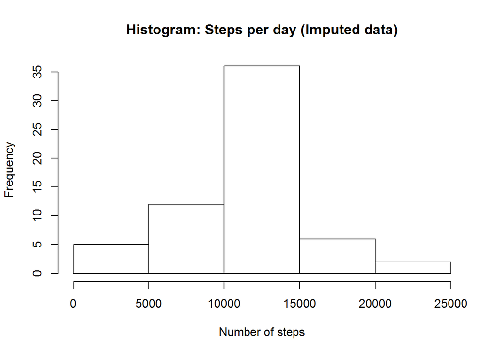

```r
StepsPerDay2 <- tapply(activity_imputed$steps, activity_imputed$date, sum)
hist(StepsPerDay2, xlab = "Number of steps", main = "Histogram: Steps per day (Imputed data)")
```

```r
mean2 <- mean(StepsPerDay2, na.rm = TRUE)
median2 <- median(StepsPerDay2, na.rm = TRUE)
```

## 4. Are there differences in activity patterns between weekdays and weekends?

### 4.1. Create a new factor variable in the dataset with two levels - “weekday” and “weekend” indicating whether a given date is a weekday or weekend day.

```r
activity_imputed$day <- ifelse(weekdays(as.Date(activity_imputed$date)) == "Saturday" | weekdays(as.Date(activity_imputed$date)) == "Sunday", "weekend", "weekday")
```

### 4.2. Make a panel plot containing a time series plot of the 5-minute interval (x-axis) and the average number of steps taken, averaged across all weekday days or weekend days (y-axis).

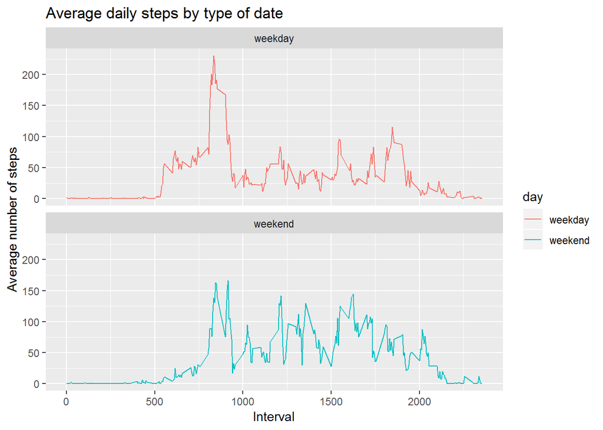

```r
activity_by_date <- aggregate(steps~interval+day,data=activity_imputed,FUN=mean,na.action=na.omit)

library(ggplot2)

plot <- ggplot(activity_by_date, aes(interval, steps, color = day)) +
        geom_line() +
        labs(title = "Average daily steps by type of date", x = "Interval", y = "Average number of steps") +
       facet_wrap(~day, ncol = 1, nrow=2)
print(plot)
```